# DNA repair protein XRCC1

Fold-switch pair **3lqcA_1xntA** — **3lqcA** vs **1xntA**

Homo sapiens

## Figure 1: Phylogenetic tree with per-cluster fold-preference heatmap.

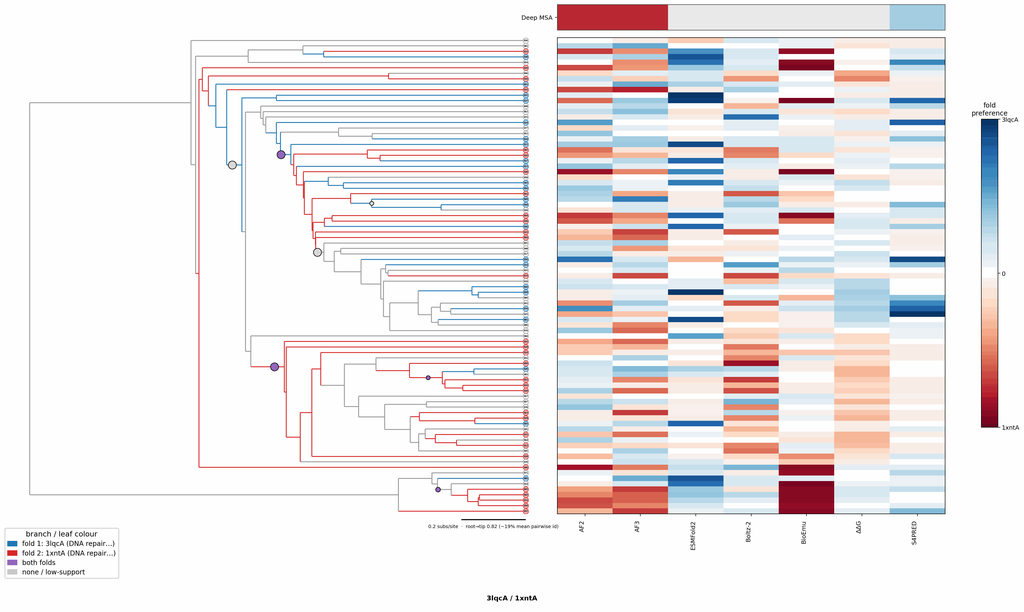

## Figure 2: Aligned overlay (both folds superposed)

The single fold-switching chain of each fold superposed by TM-align; waters hidden, any ligand shown as green sticks. Grey = structurally conserved core, colour = divergent (fold-switching) region.

3lqcA (DNA repair protein XRCC1) · dimer1xntA (DNA repair protein XRCC1) · monomer

TM-score: 0.722 · Trigger class: protein_binding

Aligned overlay

Loading...

## Figure 3: The two folds, side by side

Each fold is coloured by per-residue Cα deviation between the two superposed structures: grey ≈ conserved core, full colour = structurally divergent (fold-switching) region.

3lqcA (DNA repair protein XRCC1)

1xntA (DNA repair protein XRCC1)

0 Å5≥10 Å

3lqcA (DNA repair protein XRCC1)

Loading...

1xntA (DNA repair protein XRCC1)

Loading...

## Figure 4: Best-cluster predicted contact maps over the two true folds.

Predicted contact maps (MSA-Transformer) for the clusters best matching each fold, over the true contacts of fold 1 (upper triangle) and fold 2 (lower). Divergent contacts between clusters are the contact-level signature of fold-switching.

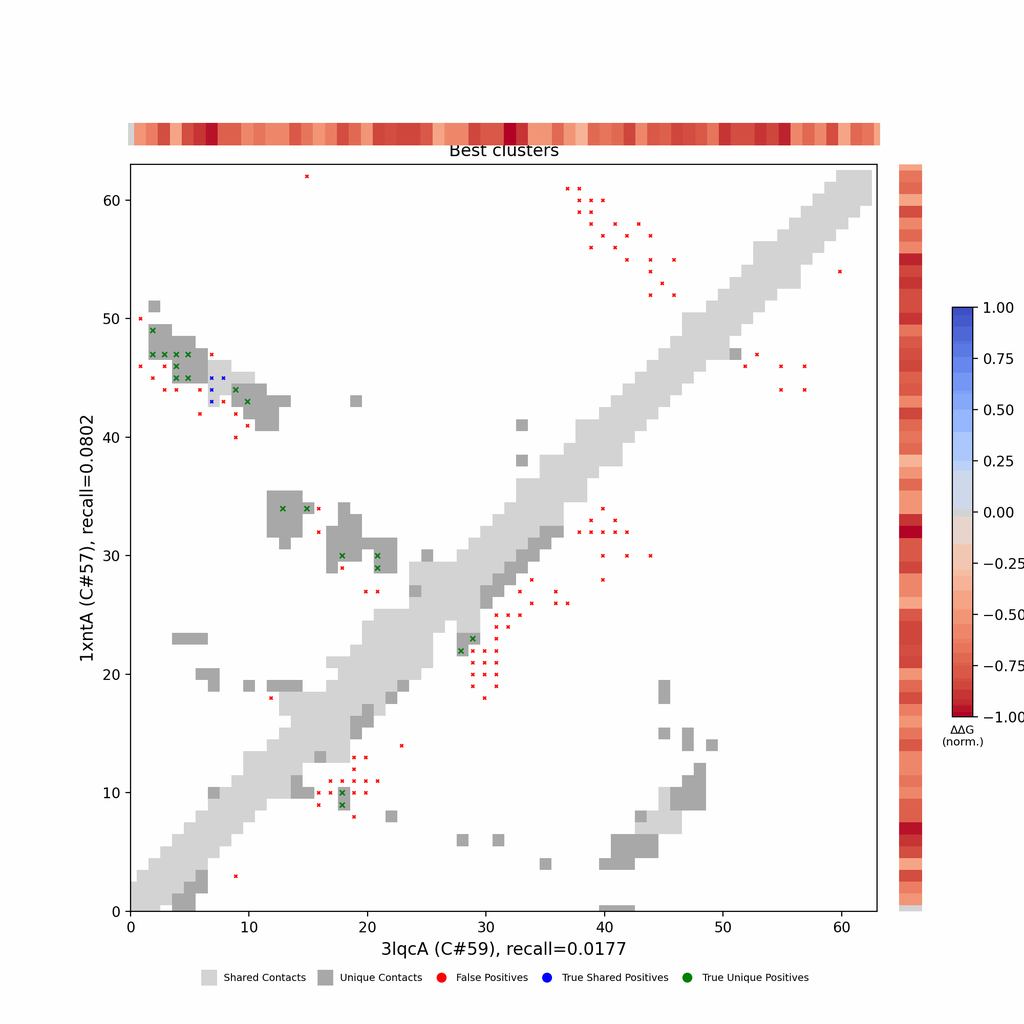

## Figure 5: Per-residue ΔΔG fold-preference contribution

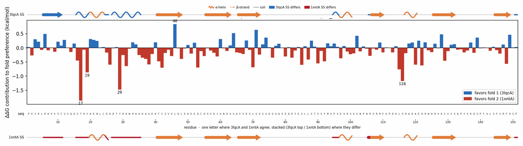

**More figures**

## Figure 6: Deep-MSA contact map panel / Best clusters contact map panel

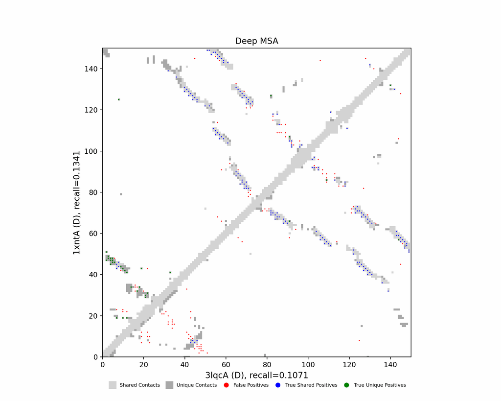

Deep-MSA contact map panel

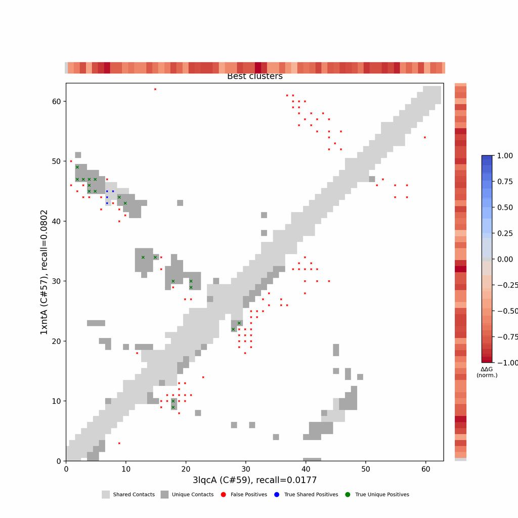

Best clusters contact map panel

## Figure 7: All clusters contact-map mosaic (small multiples).

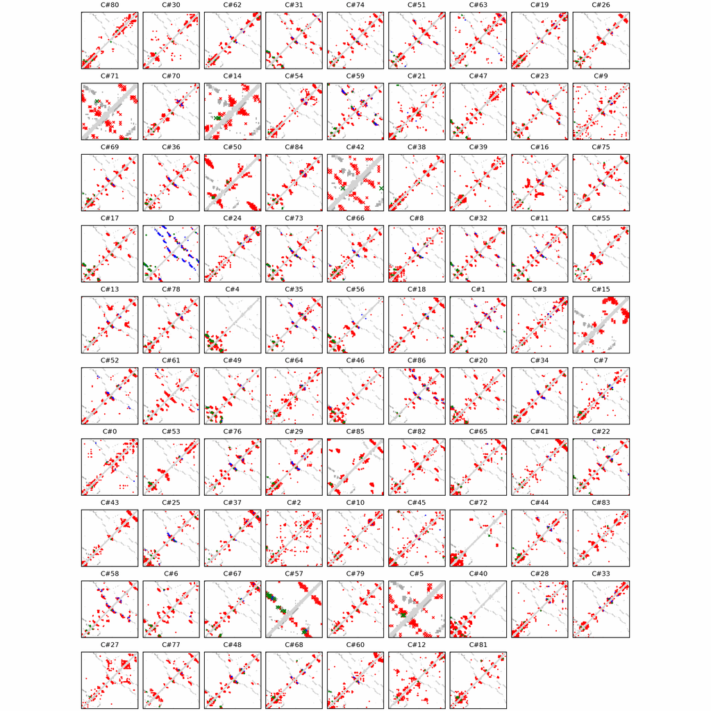

## Figure 8: Phylo null: tree with shuffled cluster fold labels.

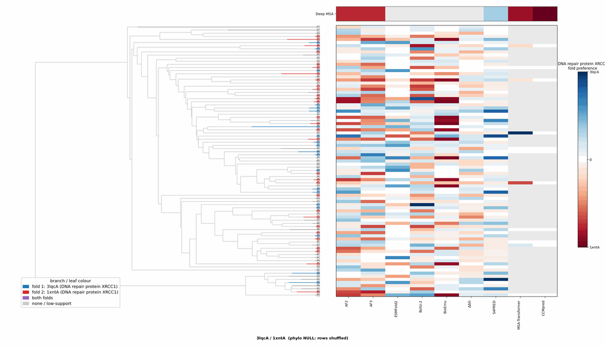

## Cluster metrics table

Per-cluster metrics underlying the figures above.

| cluster | n | neff | AF2_TM1 | AF2_TM2 | AF3_TM1 | AF3_TM2 | RE-MSAT-COM | RE-MSAT1 | RE-MSAT2 | ESM_SEQIDS | ESM_TM1 | ESM_TM2 | ΔΔG_Bias | ΔΔG_Bias_std | ΔΔG_frac_F1 | Boltz2_pref | S4PRED_pref | CCMpred_pref | BioEmu_pref |
| --- | --- | --- | --- | --- | --- | --- | --- | --- | --- | --- | --- | --- | --- | --- | --- | --- | --- | --- | --- |
| Deep | - | - | 0.78 | 0.88 | 0.78 | 0.89 | 0.38 | 0.32 | 0.38 | - | - | - | - | - | - | - | 0.06 | -0.0 | - |
| 000 | 126.0 | 8.0 | 0.33 | 0.32 | 0.36 | 0.39 | 0.0 | 0.0 | 0.0 | 008; 008; 001; 007; 007; 001; 002; 002; 003; 003 | 0.72 ± 0.02 | 0.81 ± 0.03 | -18.46 | 2.76 | 0.0 | -0.12 | -0.1 | 0.0 | -0.01 |
| 001 | 102.0 | 27.0 | 0.26 | 0.24 | 0.37 | 0.36 | 0.0 | 0.0 | 0.0 | 001; 002; 006; 004; 003; 002; 001; 006; 004; 003 | 0.74 ± 0.00 | 0.83 ± 0.03 | -8.48 | 5.63 | 0.0 | -0.02 | -0.1 | 0.0 | -0.0 |
| 002 | - | - | 0.43 | 0.41 | 0.59 | 0.68 | 0.0 | 0.0 | 0.0 | 009; 009; 004; 004; 002; 002; 001; 001; 005; 005 | 0.67 ± 0.05 | 0.65 ± 0.05 | -13.62 | 2.58 | 0.0 | -0.09 | -0.1 | 0.0 | -0.03 |
| 003 | 86.0 | 5.0 | 0.32 | 0.33 | 0.42 | 0.41 | 0.0 | 0.0 | 0.0 | 001; 002; 006; 004; 003; 002; 001; 006; 004; 003 | 0.74 ± 0.00 | 0.83 ± 0.03 | -16.28 | 4.52 | 0.0 | -0.08 | -0.1 | 0.0 | 0.01 |
| 004 | 77.0 | 6.0 | 0.74 | 0.86 | 0.78 | 0.88 | 0.02 | 0.03 | 0.02 | 009; 009; 004; 004; 002; 002; 001; 001; 005; 005 | 0.67 ± 0.05 | 0.65 ± 0.05 | -10.19 | 2.84 | 0.0 | 0.01 | -0.05 | 0.0 | -0.1 |
| 005 | 75.0 | 26.0 | 0.32 | 0.39 | 0.72 | 0.85 | 0.0 | 0.0 | 0.02 | 001; 008; 008; 001; 009; 009; 002; 002; 003; 003 | 0.73 ± 0.02 | 0.83 ± 0.02 | -8.87 | 2.01 | 0.0 | -0.03 | -0.04 | 0.0 | -0.1 |
| 006 | 75.0 | 44.0 | 0.45 | 0.49 | 0.65 | 0.67 | 0.0 | 0.01 | 0.01 | 002; 009; 004; 004; 009; 002; 001; 007; 006; 003 | 0.76 ± 0.00 | 0.83 ± 0.04 | -22.92 | 5.28 | 0.0 | -0.04 | -0.08 | 0.0 | 0.0 |
| 007 | 70.0 | 15.0 | 0.5 | 0.48 | 0.59 | 0.59 | 0.0 | 0.0 | 0.0 | 002; 002; 006; 006; 003; 003; 008; 008; 001; 001 | 0.61 ± 0.13 | 0.71 ± 0.10 | -22.73 | 2.99 | 0.0 | 0.04 | -0.11 | 0.0 | 0.01 |
| 008 | 70.0 | 6.0 | 0.42 | 0.43 | 0.42 | 0.42 | 0.0 | 0.0 | 0.0 | 001; 002; 002; 001; 007; 007; 008; 008; 003; 003 | 0.74 ± 0.03 | 0.83 ± 0.07 | -12.08 | 6.28 | 0.0 | -0.06 | -0.03 | 0.0 | 0.0 |
| 009 | 68.0 | 4.0 | 0.42 | 0.41 | 0.42 | 0.43 | 0.0 | 0.0 | 0.0 | 001; 007; 007; 001; 006; 006; 002; 002; 005; 005 | 0.74 ± 0.02 | 0.82 ± 0.03 | -5.79 | 1.68 | 0.0 | 0.0 | -0.1 | 0.0 | 0.0 |
| 010 | 68.0 | 1.0 | 0.44 | 0.49 | 0.44 | 0.48 | 0.0 | 0.0 | 0.0 | 001; 001; 008; 008; 006; 007; 006; 007; 005; 005 | 0.72 ± 0.01 | 0.81 ± 0.06 | -20.4 | 2.03 | 0.0 | -0.06 | -0.11 | 0.0 | -0.03 |
| 011 | 66.0 | 4.0 | 0.47 | 0.44 | 0.62 | 0.6 | 0.02 | 0.01 | 0.03 | 002; 004; 009; 001; 003; 006; 007; 008; 005; 010 | 0.72 ± 0.05 | 0.83 ± 0.04 | -11.81 | 5.09 | 0.0 | -0.0 | -0.08 | - | 0.01 |
| 012 | 64.0 | 28.0 | 0.55 | 0.6 | 0.58 | 0.64 | 0.0 | 0.0 | 0.0 | 009; 002; 003; 001; 007; 008; 006; 005; 010; 004 | 0.69 ± 0.08 | 0.78 ± 0.11 | -21.45 | 1.65 | 0.0 | -0.08 | -0.1 | - | 0.01 |
| 013 | 61.0 | 1.0 | 0.32 | 0.29 | 0.32 | 0.34 | 0.0 | 0.0 | 0.0 | 001; 005; 006; 007; 002; 010; 003; 004; 008; 009 | 0.58 ± 0.13 | 0.67 ± 0.15 | -12.13 | 2.49 | 0.0 | -0.01 | -0.04 | - | -0.01 |
| 014 | 58.0 | 14.0 | 0.26 | 0.29 | 0.35 | 0.36 | 0.0 | 0.0 | 0.0 | 001; 007; 006; 002; 005; 004; 008; 003; 010; 009 | 0.64 ± 0.11 | 0.74 ± 0.10 | -12.06 | 2.8 | 0.0 | 0.0 | -0.08 | - | -0.1 |
| 015 | 58.0 | 15.0 | 0.74 | 0.86 | 0.78 | 0.88 | 0.0 | 0.0 | 0.0 | 001; 008; 006; 007; 005; 009; 002; 004; 010; 003 | 0.57 ± 0.17 | 0.66 ± 0.19 | -12.54 | 3.98 | 0.0 | 0.0 | -0.07 | - | -0.09 |
| 016 | 57.0 | 23.0 | 0.44 | 0.42 | 0.64 | 0.7 | 0.0 | 0.0 | 0.0 | - | - | - | -26.84 | 3.82 | 0.0 | -0.07 | -0.1 | - | -0.0 |
| 017 | 56.0 | 6.0 | 0.33 | 0.32 | 0.37 | 0.41 | 0.0 | 0.0 | 0.0 | - | - | - | -7.48 | 4.92 | 0.0 | -0.01 | -0.09 | - | -0.0 |
| 018 | 54.0 | 15.0 | 0.42 | 0.47 | 0.53 | 0.61 | 0.0 | 0.0 | 0.0 | - | - | - | -15.5 | 3.64 | 0.0 | -0.08 | -0.1 | - | -0.0 |
| 019 | 49.0 | 12.0 | 0.42 | 0.42 | 0.37 | 0.4 | 0.0 | 0.0 | 0.0 | - | - | - | -5.87 | 1.22 | 0.0 | -0.05 | -0.09 | - | 0.01 |
| 020 | 48.0 | 1.0 | 0.76 | 0.87 | 0.78 | 0.88 | 0.0 | 0.02 | 0.0 | - | - | - | -13.26 | 6.97 | 0.0 | -0.0 | -0.05 | - | -0.1 |
| 021 | 47.0 | 29.0 | 0.43 | 0.49 | 0.7 | 0.81 | 0.0 | 0.0 | 0.0 | - | - | - | -22.06 | 1.17 | 0.0 | -0.04 | -0.11 | - | -0.01 |
| 022 | 46.0 | 3.0 | 0.58 | 0.59 | 0.38 | 0.39 | 0.0 | 0.01 | 0.0 | - | - | - | -12.61 | 3.79 | 0.0 | -0.01 | -0.09 | - | 0.02 |
| 023 | 45.0 | 10.0 | 0.52 | 0.57 | 0.7 | 0.82 | 0.0 | 0.0 | 0.0 | - | - | - | -11.92 | 7.8 | 0.0 | -0.09 | -0.1 | - | -0.0 |
| 024 | 45.0 | 15.0 | 0.34 | 0.28 | 0.39 | 0.42 | 0.0 | 0.01 | 0.0 | - | - | - | -10.24 | 6.24 | 0.0 | -0.0 | 0.06 | - | -0.0 |
| 025 | 45.0 | 8.0 | 0.41 | 0.49 | 0.35 | 0.42 | 0.01 | 0.01 | 0.0 | - | - | - | -5.78 | 3.67 | 0.0 | -0.04 | 0.1 | - | -0.01 |
| 026 | 44.0 | 8.0 | 0.49 | 0.6 | 0.4 | 0.48 | 0.0 | 0.0 | 0.0 | - | - | - | -9.25 | 4.67 | 0.0 | -0.0 | -0.1 | - | -0.06 |
| 027 | 43.0 | 9.0 | 0.39 | 0.4 | 0.36 | 0.35 | 0.0 | 0.0 | 0.0 | - | - | - | -10.93 | 6.42 | 0.0 | -0.0 | -0.1 | - | -0.0 |
| 028 | 43.0 | 6.0 | 0.46 | 0.49 | 0.43 | 0.48 | 0.0 | 0.0 | 0.0 | - | - | - | -21.86 | 1.13 | 0.0 | -0.08 | -0.11 | - | 0.0 |

[output cut: 58 more lines]